# Mississauga Emitters

## Some R Fundamentals

#### Vectors

A vector in `R` is just a list of things (usually numbers or words) such as (1, 2, 3) or (“hello”, “goodbye”, “apple”). To create a vector in `R` with the name `my_vector`, run the following code (press the green play in the top right).

```r
my_vector <- c(1, 2, 3) # this line creates the vector
my_vector # this line prints it out
```

```
## [1] 1 2 3
```

Here, `c` is a function that creates vectors, and `<-` saves the thing on the right to the name on the left. Everything that comes after a `#` on a line is optional and called a comment. It is ignored by the computer, and exists as a place to write notes.

A data frame in `R` is almost identical to an excel spreadsheet, if the spreadsheet only contained the data. Data frames consist of several columns of vectors in a row. To create a dataframe in `R` with the name `my_dataframe`, run the following code (press the green play in the top right).

```r
my_vector_numbers_1 <- c(1,2,3) # create a numeric vector
my_vector_numbers_2 <- c(3,1,2) # create another numeric vector

my_vector_words <- c("hello", "goodbye", "apple") # create a character vector (vector of words)

my_dataframe <- data.frame(my_vector_numbers_1, my_vector_numbers_2, my_vector_words) # create the dataframe
my_dataframe # print it out
```

```
##   my_vector_numbers_1 my_vector_numbers_2 my_vector_words
## 1                   1                   3           hello
## 2                   2                   1         goodbye
## 3                   3                   2           apple
```

More in depth information on data frames (also called tibbles) can be found [here](https://r4ds.had.co.nz/tibbles.html).

#### Functions

Functions work by taking an input, some number of arguments separated by commas, and return an output. You can tell something is a function when there are parenthesis. We’ll be using many functions such as `ggplot` or `addCircleMarkers` to create our visualizations. For example, we used two functions above, `c` to make a vector, and `data.frame` to make a dataframe.

One thing that will be done with functions is combining them. There are 2 ways to do this. When using ggplot to make static plots, the `+` symbol combines functions, telling the computer to keep adding on to a plot. The other is called a pipe, and is written `%>%`. This takes whatever is on the left side of the pipe, and makes it the first argument to whatever is on the right side of the pipe. For example, we can use the function `sum` to add up numbers in a vector with the following command.

```r
my_vector %>% # use the pipe to run sum(my_vector_numbers)
  sum()
```

```
## [1] 6
```

More in depth information on functions can be found [here](https://r4ds.had.co.nz/functions.html).

## Static Visualizations

Now we’ll begin visualizing our data!

The first thing to do whenever doing data analysis is to look at the data:

```r
View(miss_ghg_data)
```

Here, we have data for 13 distinct greenhouse gas emitting sites in the city of Mississauga, and we have data for these sites between the years 2010 and 2018. Can you tell what each row represents?

Data were collected from [this website](https://data.ontario.ca/en/dataset/greenhouse-gas-emissions-reporting-by-facility).

### Examples

Now, we’ll actually make some visualizations. We’ll do this using the package `ggplot2`, which is an excellent framework for data visualization. It is used by organizations including The Economist and The Guardian for many of their visuals.`ggplot2` visuals can be taken in Adobe Illustrator afterwards to make professional quality visuals.

A (complicated) cheatsheet of how to use `ggplot2` can be found here: https://rstudio.com/wp-content/uploads/2015/03/ggplot2-cheatsheet.pdf

First, we’ll use the example data frame to make a simple point plot. The following code creates a simple plot when run

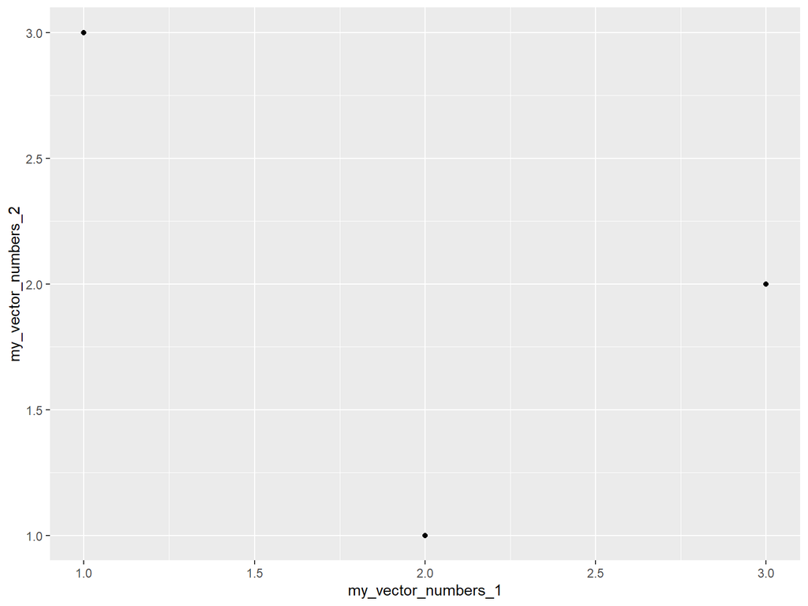

```r
ggplot(my_dataframe,
       aes(x = my_vector_numbers_1, y = my_vector_numbers_2)) +
  geom_point()
```

`ggplot2` works by layering on levels of visualization. The first layer, `ggplot`, tells to computer to prepare a plot. The first line is the data, and the second line, `aes(...)` contains instructions for how to link the data to the visualization. Here, `x = my_vector_numbers_1` tells the computer that the x-location of points comes from the `my_vector numbers_1` column in `my_dataframe`, and `y = my_vector_numbers_2` tells the computer that the y-location of points comes from the `my_vector numbers_2` column in `my_dataframe`. The second layer, `geom_point` tells the computer to make a point plot.

Now, lets try creating a visual using our data, CO2 equivalent emissions for each facility over time.

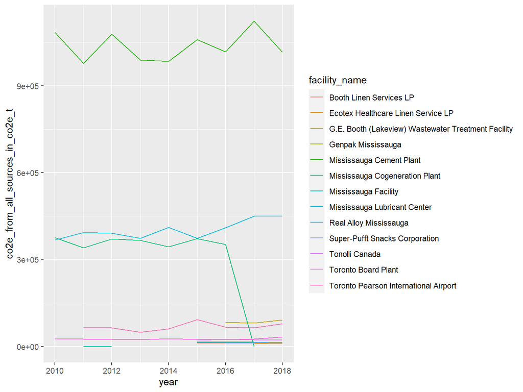

```r
ggplot(miss_ghg_data,
       aes(x = year, y = co2e_from_all_sources_in_co2e_t, color = facility_name)) +
  geom_line()
```

What do you like about this visual, and what is bad about it? Can you tell how the code created this visual?

Now, we’ll add more complexity to the plot by cleaning up the labels.

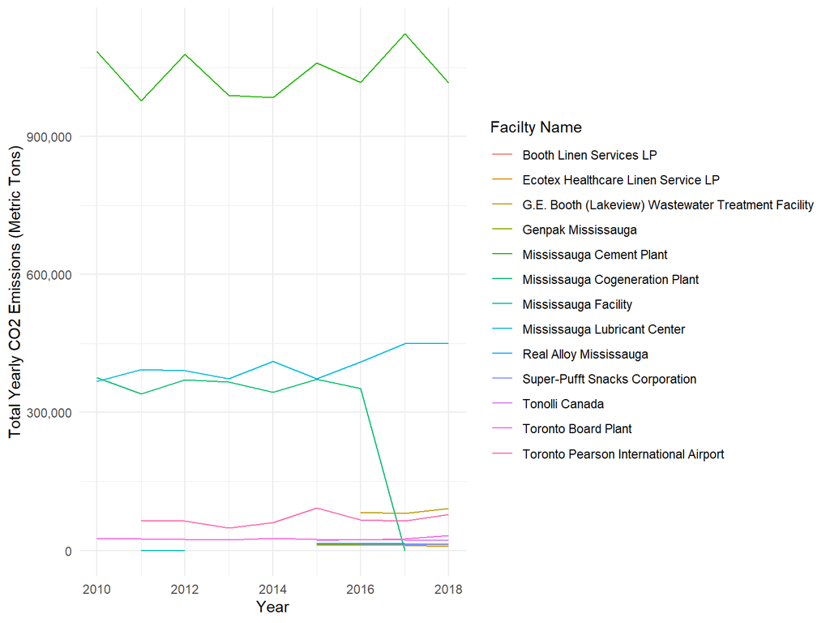

```r
ggplot(miss_ghg_data ,
       aes(x = year, y = co2e_from_all_sources_in_co2e_t, color = facility_name)) +
  geom_line() +
  labs(x = "Year",
       y = "Total Yearly CO2 Emissions (Metric Tons)",
       color = "Facilty Name") +
  scale_y_continuous(labels = comma) + # make y-axis labels full numbers
  theme_minimal() # makes graph look neater (in my opinion)
```

Now, we’ll use a command called `filter` to declutter the graph by only looking at the top 3 emitters. We’ll also switch to using a colorblind friendly color palette, which should always be done when encoding information in color.

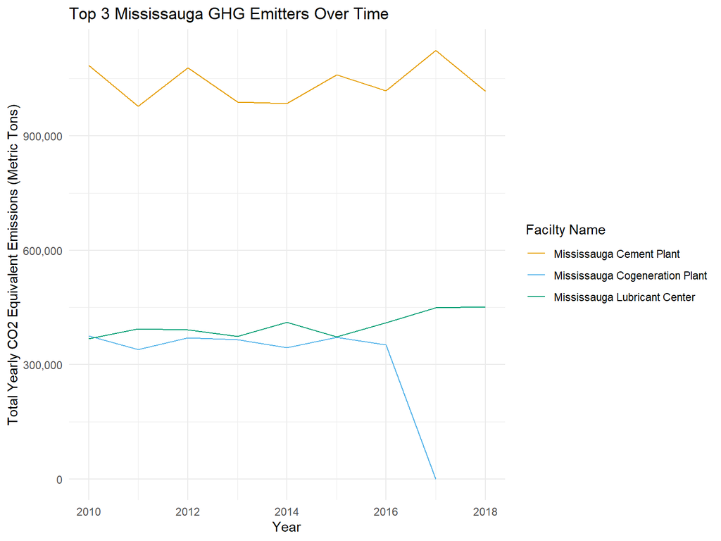

```r
# set colorblind friendly colors as a vector of hexadecimal representions
colorblind_colors <- c("#E69F00", "#56B4E9", "#009E73", "#F0E442", "#0072B2", "#D55E00", "#CC79A7")



filter(miss_ghg_data, facility_name %in% c("Mississauga Cement Plant",
                                     "Mississauga Cogeneration Plant",
                                     "Mississauga Lubricant Center")) %>%
  ggplot(aes(x = year, y = co2e_from_all_sources_in_co2e_t,
             color = facility_name)) +
  geom_line() +
  labs(x = "Year",
       y = "Total Yearly CO2 Equivalent Emissions (Metric Tons)",
       color = "Facilty Name",
       title = "Top 3 Mississauga GHG Emitters Over Time") +
  scale_y_continuous(labels = comma) +
  scale_color_manual(values = colorblind_colors) +
  theme_minimal() # makes graph look neater (in my opinion)
```

Now, we’ll emphasize that these data are collected yearly by adding points at each year of collection.

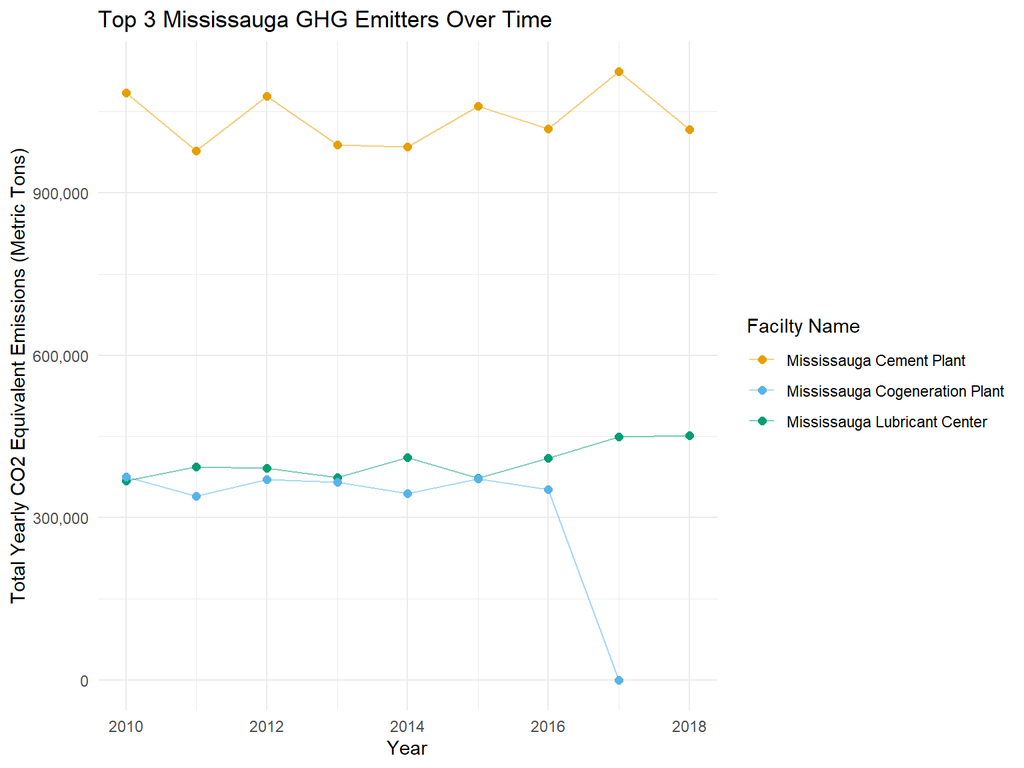

```r
filter(miss_ghg_data, facility_name %in% c("Mississauga Cement Plant",
                                     "Mississauga Cogeneration Plant",
                                     "Mississauga Lubricant Center")) %>%
  ggplot(aes(x = year, y = co2e_from_all_sources_in_co2e_t,
             color = facility_name)) +
  geom_line(alpha = 0.5) + # makes lines semi-transparent (0 is fully transparent, 1 is fully opaque)
  geom_point(size = 2) +
  labs(x = "Year",
       y = "Total Yearly CO2 Equivalent Emissions (Metric Tons)",
       color = "Facilty Name",
       title = "Top 3 Mississauga GHG Emitters Over Time") +
  scale_y_continuous(labels = comma) +
  scale_color_manual(values = colorblind_colors) +
  theme_minimal() # makes graph look neater (in my opinion)
```

### Your Turn!

Look at the three aggreagated datasets

```r
View(facility_emissions)
View(owner_emissions)
View(yearly_emissions)
```

What visualizations could be made from these? What kind of plots have you seen before for data such as these? If you come up with an idea, I encourage you to draw out a sketch of what you want the visual to look like. Then, try and build them! We’ll work together for this.

```r
# CODE GOES HERE
```

## Interactive Maps

Now lets try mapping things! We’ll be using the `R` package `rleaflet` to interface with the javascript library `leaflet`, which is the web standard for interactive maps. Pretty much anytime you see an interactive map on the web, it is powered by leaflet.

The reference manual for `rleaflet` can be found here: https://rstudio.github.io/leaflet/

```r
View(miss_ghg_data)
```

### Examples

In contrast to `ggplot`, `leaflet` uses pipes (`%>%`) to add layers. We’ll be plotting average yearly facility CO2 equivalent emissions.

```r
facility_emissions %>%
  leaflet() %>%
  addTiles() %>%
  addCircleMarkers()
```

```
## Assuming "longitude" and "latitude" are longitude and latitude, respectively
```

[interactive chart not shown]

Can you tell how these functions could combine to make a map?

Now we’ll add a layer of complexity, and change the size of points based on their emissions. I’ve written a function below called normalize, which makes shrinks vectors to be between -1 and 1 to ease sizing on the map. Don’t worry about the code for creating the function, instead focus on how to code inside `addCircleMarkers` changes the size of points.

```r
normalize <- function(vector) { # makes values of a vector between -1 and 1 to ease sizing
  vector / max(abs(vector))
}

facility_emissions %>%
  leaflet() %>%
  addTiles() %>%
  addCircleMarkers(radius = ~100 * normalize(average_yearly_carbon_dioxide_co2_in_co2e_t),
                   stroke = FALSE, fillOpacity = 0.5)
```

```
## Assuming "longitude" and "latitude" are longitude and latitude, respectively
```

[interactive chart not shown]

Now, another layer of complexity adds coloring by emissions (using the viridis palette, a common colorblind friendly color scale), and clean up the map by switching to a more minimal tile background.

```r
average_co2e_colors <- colorNumeric( # prepares a color palette for our color scale
  palette = "viridis",
  domain = facility_emissions$average_yearly_co2e_from_all_sources_in_co2e_t)

facility_emissions %>%
  leaflet() %>%
  addProviderTiles(providers$CartoDB.Positron) %>% # CartoDB is a provider of basemaps, chosen because the map is less cluttered
  addCircleMarkers(radius = ~ 100 * normalize(average_yearly_carbon_dioxide_co2_in_co2e_t),
                   color = ~ average_co2e_colors(average_yearly_carbon_dioxide_co2_in_co2e_t),
                   stroke = FALSE, fillOpacity = 0.5) %>%
  addLegend("bottomright", # creates a legend in the bottom right of the map
            pal = average_co2e_colors, # colors for the legend to use
            values = ~average_yearly_carbon_dioxide_co2_in_co2e_t, # the data our legend applies to
    title = "Average Yearly CO2 Equivalent Emissions",
    opacity = 0.5
  )
```

```
## Assuming "longitude" and "latitude" are longitude and latitude, respectively
```

[interactive chart not shown]

### Your Turn!

What visualizations could be made from these? What kind of plots have you seen before for data such as these? If you come up with an idea, I encourage you to draw out a sketch of what you want the visual to look like. Then, try and build them! We’ll work together for this.

```r
# CODE GOES HERE
```

## Further Resources

- [D3](https://d3js.org/) is another web standard for data visualization, and is written in javascript. It is much more complicated, but if you are comfortable with web development, might be a more natural fit. Organizations such as the New York Times and The Pudding do almost all of their final visuals in D3.
- [R for Data Science](https://r4ds.had.co.nz/) is a great overview of one framework for doing data work in R, including data preparation which was done behind the scenes.
- My [GitHub Repo of Data Prep](https://github.com/grahamammal/Mississuaga-Workshop) might be of interest to people who want to see data cleaning in action. Warning! Some of the manipulations done are a little fancy!
- [leaflet](https://leafletjs.com/): here is a link to the javascript version of leaflet for those more familiar with web development.